# 第8回 データを分析する（1）：相関分析と散布図

行動計量学（行動科学分析法入門）

小野原 彩香

令和8年度

## 本日の目標

1. 相関係数の意味を理解し，2変数の関係を解釈できる
2. Rで相関係数を計算し（`cor()`），有意性検定を実行できる（`cor.test()`）
3. 散布図と相関係数を組み合わせてデータを説明できる
4. **発展**：相関係数 *r* の性質と，`cor.test()` の t統計量の式を，自分で導ける

## 準備：パッケージの読み込み

この回のコードは，すべて `tidyverse` を読み込んだ状態で動きます。 RStudioを起動したら，**まずこれを実行してください。**

```r
library(tidyverse)
```

> 毎回必要です。読み込まないまま `filter()` や `ggplot()` を使うと， 「関数が見つかりません」というエラーになります。

## 1. 相関とは

### 2変数の関係を数値で表す

**相関（correlation）**とは，2つの変数の間にある直線的な関係の強さと方向を表す指標です。

| 相関の方向 | 意味 | 例 |
| --- | --- | --- |
| **正の相関** | 一方が増えると他方も増える | 身長と体重 |
| **負の相関** | 一方が増えると他方は減る | 睡眠時間と疲労度 |
| **無相関** | 2変数に直線的関係がない | 誕生月と学力 |

### ピアソンの積率相関係数 *r*

$$r = \frac{\sum(x_i - \bar{x})(y_i -
\bar{y})}{\sqrt{\sum(x_i - \bar{x})^2 \cdot \sum(y_i -
\bar{y})^2}}$$

- 値の範囲：**-1 ≤ r ≤ 1**
- *r* = +1：完全な正の相関
- *r* = -1：完全な負の相関
- *r* = 0：相関なし

**導出①**：$r$ は「共分散を，2つのばらつきで割ったもの」**

上の式の分子と分母を，どちらも $n-1$ で割ってみます。値は変わりません。

分子を $n-1$ で割ったものが**共分散**です（R の `cov()` と同じ定義です）。

$$\mathrm{Cov}(x,y) =
\frac{1}{n-1}\sum(x_i - \bar{x})(y_i - \bar{y})$$

分母を $n-1$ で割ったものは，2つの標準偏差の積になります（R の `sd()` と同じ定義です）。

$$\frac{1}{n-1}\sqrt{\sum(x_i-\bar{x})^2
\cdot \sum(y_i-\bar{y})^2} = \sqrt{\frac{\sum(x_i-\bar{x})^2}{n-1}}
\cdot \sqrt{\frac{\sum(y_i-\bar{y})^2}{n-1}} = s_x \, s_y$$

したがって

$$r = \frac{\mathrm{Cov}(x,y)}{s_x \,
s_y}$$

共分散は「2つが一緒に動く量」ですが，単位が「cm×cm」のように掛け算になっていて大きさの比較ができません。そこで**それぞれのばらつきで割って単位を消した**のが $r$ です。

各データを標準化して $z_x = (x_i - \bar{x})/s_x$，$z_y = (y_i - \bar{y})/s_y$ と置くと（R の `scale()` がこの計算です），同じことが次のように書けます。

$$r = \frac{1}{n-1}\sum z_{x_i}
z_{y_i}$$

$r$ は**標準化した値どうしの積を合計して $n-1$ で割ったもの**である，ということです。

**数値で確かめる**：iris のがく片の長さと花びらの長さ（$n = 150$）では，本文の定義式が $0.8717538$，`cor()` が $0.8717538$，`cov(x, y) / (sd(x) * sd(y))` が $0.8717538$，$\frac{1}{n-1}\sum z_x z_y$ も $0.8717538$ で，すべて一致します。

**単位を変えても $r$ は変わりません。** がく片を cm から mm に（$\times 10$），花びらを cm からインチに（$\div 2.54$）換算しても $r = 0.8717538$ のままです。分子も分母も同じ倍率で変わるので，割り算で消えるからです。

> **$n$ で割る流儀もあります。** 教科書によっては，共分散や標準偏差を $n-1$ ではなく $n$ で割って定義します。 $r$ は共分散を標準偏差の積で割った**比**なので，どちらの流儀でも $0.8717538$ と同じ値になります。

> **この資料は R に合わせて $n-1$ で統一します。** `sd()`・`cov()`・`scale()` がすべてこの定義なので， 書かれている式をそのまま R で打って確かめられます。

**使った数学**：平均・分散・共分散の定義と，割り算で単位が消えること。

**導出②**：なぜ $-1 \le r \le 1$ に収まるのか**

標準化した値には，定義からすぐ出る性質が2つあります。

$$\sum z_x^2 = n-1, \qquad \sum z_y^2 =
n-1, \qquad \sum z_x z_y = (n-1)\,r$$

（3つめは導出①の $r = \frac{1}{n-1}\sum z_x z_y$ を移項しただけです。）

ここで**二乗は決して負にならない**という，ただそれだけの事実を使います。

$$\sum (z_x - z_y)^2 \ge 0$$

左辺を展開すると

$$\sum z_x^2 - 2\sum z_x z_y + \sum z_y^2
= (n-1) - 2(n-1)r + (n-1) = 2(n-1)(1 - r)$$

これが $0$ 以上で，$n \ge 2$ なら $2(n-1) > 0$ ですから $1 - r \ge 0$，つまり $r \le 1$ が出ます。

同じことを足し算の側でやると

$$\sum (z_x + z_y)^2 = 2(n-1)(1 + r) \ge
0$$

から $r \ge -1$ が出ます。あわせて $-1 \le r \le 1$ です。

**等号はいつ成り立つか。** $\sum(z_x - z_y)^2 = 0$ になるのは，すべての個体で $z_x = z_y$ のときだけです。これは「標準化したら完全に同じ値」，つまり $y$ が $x$ の1次式でぴったり書ける（すべての点が1本の右上がりの直線に乗る）場合です。$r = -1$ は右下がりの直線です。

**数値で確かめる**：iris では $n - 1 = 149$ で，$\sum z_x^2 = 149$，$\sum z_x z_y = 129.8913$（$= 149 \times 0.8717538$）です。 $\sum(z_x - z_y)^2 = 38.2174$，理論値 $2(n-1)(1-r) = 2 \times 149 \times (1 - 0.8717538) = 38.2174$ で一致します。 足し算の側も $\sum(z_x + z_y)^2 = 557.7826$，$2(n-1)(1+r) = 557.7826$ で一致します。 **`scale()` で標準化すれば，そのまま手元で確かめられます。**

**使った数学**：二乗は負にならない，という事実だけ。特別な定理は使っていません。

### 相関係数の目安（絶対値）

|  | r |
| --- | --- |
| 0.0〜0.2 | ほとんど相関なし |
| 0.2〜0.4 | 弱い相関 |
| 0.4〜0.6 | 中程度の相関 |
| 0.6〜0.8 | 強い相関 |
| 0.8〜1.0 | 非常に強い相関 |

> 目安であり，分野や文脈によって解釈が変わることに注意。

## 2. 散布図で関係を「見る」

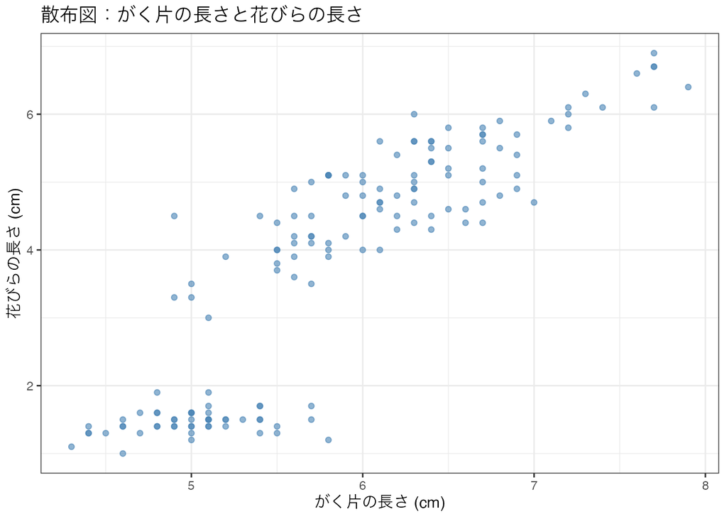

```r
# iris データ：がく片の長さと花びらの長さの散布図
ggplot(iris, aes(x = Sepal.Length, y = Petal.Length)) +
  geom_point(color = "steelblue", alpha = 0.6) +
  labs(title = "散布図：がく片の長さと花びらの長さ",
       x = "がく片の長さ (cm)", y = "花びらの長さ (cm)") +
  theme_bw()
```

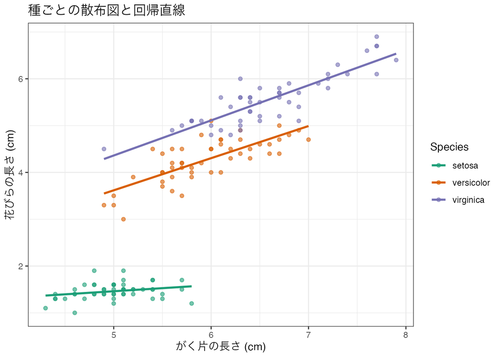

```r
# 種ごとに色を分ける
ggplot(iris, aes(x = Sepal.Length, y = Petal.Length, color = Species)) +
  geom_point(alpha = 0.6) +
  geom_smooth(method = "lm", se = FALSE) +
  scale_color_brewer(palette = "Dark2") +
  labs(title = "種ごとの散布図と回帰直線",
       x = "がく片の長さ (cm)", y = "花びらの長さ (cm)") +
  theme_bw()
```

## 3. Rで相関係数を計算する

### cor()：相関係数の計算

```r
# 2変数の相関係数
cor(iris$Sepal.Length, iris$Petal.Length)
```

```
## [1] 0.8717538
```

```r
# 複数変数の相関行列
iris |>
  select(Sepal.Length, Sepal.Width, Petal.Length, Petal.Width) |>
  cor()
```

```
##              Sepal.Length Sepal.Width Petal.Length Petal.Width
## Sepal.Length    1.0000000  -0.1175698    0.8717538   0.8179411
## Sepal.Width    -0.1175698   1.0000000   -0.4284401  -0.3661259
## Petal.Length    0.8717538  -0.4284401    1.0000000   0.9628654
## Petal.Width     0.8179411  -0.3661259    0.9628654   1.0000000
```

```r
# 四捨五入して見やすく
iris |>
  select(Sepal.Length, Sepal.Width, Petal.Length, Petal.Width) |>
  cor() |>
  round(2)
```

```
##              Sepal.Length Sepal.Width Petal.Length Petal.Width
## Sepal.Length         1.00       -0.12         0.87        0.82
## Sepal.Width         -0.12        1.00        -0.43       -0.37
## Petal.Length         0.87       -0.43         1.00        0.96
## Petal.Width          0.82       -0.37         0.96        1.00
```

## 4. cor.test()：相関の有意性検定

相関係数が「偶然ではなく本当に存在する」かどうかを検定します。

### 仮説の設定

- **帰無仮説 H₀**：母相関係数 ρ = 0（相関はない）
- **対立仮説 H₁**：母相関係数 ρ ≠ 0（相関がある）

```r
# 相関の有意性検定
cor.test(iris$Sepal.Length, iris$Petal.Length)
```

```
##
##  Pearson's product-moment correlation
##
## data:  iris$Sepal.Length and iris$Petal.Length
## t = 21.646, df = 148, p-value < 2.2e-16
## alternative hypothesis: true correlation is not equal to 0
## 95 percent confidence interval:
##  0.8270363 0.9055080
## sample estimates:
##       cor
## 0.8717538
```

### 結果の読み方

```
Pearson's product-moment correlation

t = 21.646, df = 148, p-value < 2.2e-16
95 percent confidence interval:
 0.8270363 0.9055080
sample estimates:
      cor
0.8717538
```

| 項目 | 意味 |
| --- | --- |
| `t` | t統計量 |
| `df` | 自由度（n - 2） |
| `p-value` | p値（< 0.05 なら有意） |
| `95% CI` | 相関係数の95%信頼区間 |
| `cor` | 標本相関係数 r の推定値 |

**導出③**：`cor.test()` の $t$ 値はどこから来るのか ―― 「強い」と「有意」は別**

`cor.test()` は $r$ から次の統計量を作り，自由度 $n - 2$ の $t$ 分布と照らして $p$ 値を出しています。

$$t =
\frac{r\sqrt{n-2}}{\sqrt{1-r^2}}$$

自由度が $n-2$ なのは，直線を当てるのに切片と傾きの2つを標本から決めているためです。

**数値で確かめる**：iris では $r = 0.8717538$，$n = 150$ なので

$$t = \frac{0.8717538 \times
\sqrt{148}}{\sqrt{1 - 0.8717538^2}} = 21.6460$$

上の出力の `t = 21.646, df = 148` と一致します。

**この式の右辺で，$n$ は $r$ とは別のところに入っています。** $r$ を固定したまま $n$ だけ動かすと，$t$ は $\sqrt{n}$ におよそ比例して大きくなり，$p$ は小さくなります。

| $r$ | $n$ | $t$ | $p$ |
| --- | --- | --- | --- |
| 0.8718 | 4 | 2.52 | 0.128 |
| 0.8718 | 5 | 3.08 | 0.054 |
| 0.8718 | 10 | 5.03 | 0.0010 |
| 0.8718 | 150 | 21.65 | $1.0 \times 10^{-47}$ |

$r = 0.87$ という**非常に強い**相関でも，$n = 4$ なら有意になりません。

逆の方向も見てみます。iris のがく片の**長さと幅**は $r = -0.1176$（ほとんど相関なし）で，$n = 150$ では $t = -1.44$，$p = 0.152$ となり有意ではありません。しかし $r$ が同じまま $n$ が増えると，

| $r$ | $n$ | $p$ |
| --- | --- | --- |
| −0.1176 | 150 | 0.152 |
| −0.1176 | 279 | 0.050 |
| −0.1176 | 1000 | 0.00019 |
| −0.1176 | 2000 | $1.3 \times 10^{-7}$ |

$n = 279$ を超えると有意になります。**関係の強さは何も変わっていないのに，です。**

> **「相関が強い」と「相関が有意」は，別のことを言っています。** $r$ は関係の強さそのもの（$n$ を増やしても動かない），$p$ はその関係が偶然で説明しにくいかどうか（$n$ を増やせば小さくなる）。だから報告では $r$ と $p$ を**必ず両方**書きます。本文5節の書き方 `r(148) = .87, p < .001` は，まさにその2つを並べたものです。

なお，$t$ 分布の密度関数そのものを導くのは，この科目の範囲外です。ここでは「$r$ と $n$ から $t$ が決まる」という関係だけを押さえてください。

**有意であっても，強くても，因果があるという意味にはなりません。** これは標本の揺れの話だけをしていて，なぜ2つが一緒に動くのかには何も答えていないからです。第6節を必ず併せて読んでください。

**使った数学**：平方根と分数の変形。自由度の数え方（第10回・第13回でも同じ考え方を使います）。

## 5. 結果の報告

論文・レポートでの記述例：

> がく片の長さと花びらの長さの間には強い正の相関が見られた，*r*(148) = .87，*p* < .001。

**APA形式での相関係数の書き方：** - イタリック体で `r` - 括弧内に自由度（= n - 2） - p 値は .001, .01, .05 の水準で報告

## 6. 注意：相関と因果

> **相関関係は因果関係を意味しない！**

相関があっても，それは「一緒に変化する」ことを示すだけで， 「原因と結果」の関係があるとは限りません。

- アイスクリームの売り上げと溺死事故件数の相関 → 第3の変数（気温）
- 「見かけ上の相関」（spurious correlation）に注意

## 演習

### 演習1：散布図の作成

`mtcars` データを使って，馬力（`hp`）と燃費（`mpg`）の散布図を作成してください。 - 回帰直線（`geom_smooth(method = "lm")`）を追加する - 適切なタイトル・軸ラベルをつける

```r
ggplot(mtcars, aes(x = ___, y = ___)) +
  geom_point(color = "___") +
  geom_smooth(method = "lm", se = TRUE) +
  labs(title = "___", x = "___", y = "___") +
  theme_bw()
```

### 演習2：相関係数の計算と検定

1. `mtcars` の `hp` と `mpg` の相関係数を計算してください
2. `cor.test()` で有意性を検定し，結果を解釈してください

```r
# 相関係数
cor(mtcars$___, mtcars$___)

# 有意性検定
cor.test(mtcars$___, mtcars$___)
```

### 演習3：相関行列

`mtcars` の `mpg`, `hp`, `wt`, `qsec`（0から1/4マイルまでの加速時間・秒）の相関行列を作成し， どの変数の組み合わせが最も強い相関を持つか調べてください。

### 演習4：結果の記述

演習2の結果を，論文・レポートの記述として1〜2文でまとめてください。 （例：「〇〇と〇〇の間には，〇〇な相関が見られた，r(〇〇) = .〇〇, p < .〇〇。」）

> このデータの $r$ は**負の値**になります。符号を落とさないでください。 「馬力が大きいほど燃費が悪い」という向きを，日本語でも書き添えます。

## 本日のまとめ

- 相関係数 *r* は -1〜+1 の範囲で2変数の直線的関係を表す
- `cor()` で相関係数，`cor.test()` で有意性検定
- 散布図と組み合わせてデータを理解する
- **相関関係 ≠ 因果関係**

## 宿題・予習

- 演習2・3の結果をスクリプトに保存
- 次回は**カテゴリデータの分析（カイ二乗検定）**を学びます
- 教科書のカイ二乗検定に関する章を読んでおく